# Feature Engineering Axa’s Challenge

Lecture du dataset en ayant au préalable remplacé les Nans avec la méthode des plus proches voisins.

```r
train <- read.table("/home/sid2018-1/Bureau/challenge Axa/train_imputed.csv", sep =',',header=TRUE)
```

Nous précisons à R quelles sont nos variables catégorielles

```r
train$le_csp=as.factor(train$le_csp)
train$le_marque=as.factor(train$le_marque)
train$le_type_vehicule=as.factor(train$le_type_vehicule)
train$age_label=as.factor(train$age_label)
```

```r
attach(train)
```

Quelques stats descriptives sur nos données

```r
summary(train)
```

```
      Age         Benefice.net.annuel Coefficient.bonus.malus Cout.entretien.annuel
 Min.   :  0.00   Min.   :-35.721     Min.   : 50             Min.   : 520
 1st Qu.: 26.00   1st Qu.:  5.991     1st Qu.: 90             1st Qu.: 726
 Median : 32.00   Median : 14.386     Median :100             Median : 794
 Mean   : 36.09   Mean   : 16.976     Mean   :100             Mean   : 793
 3rd Qu.: 42.00   3rd Qu.: 30.344     3rd Qu.:110             3rd Qu.: 863
 Max.   :198.00   Max.   : 78.115     Max.   :154             Max.   :1145

 Kilometres.parcourus.par.mois Niveau.de.vie   Prime.mensuelle Salaire.annuel
 Min.   :200.0                 Min.   : -558   Min.   : 0.00   Min.   :   880
 1st Qu.:411.0                 1st Qu.: 2335   1st Qu.: 9.00   1st Qu.: 16795
 Median :614.0                 Median : 3652   Median :16.00   Median : 25955
 Mean   :605.7                 Mean   : 4207   Mean   :18.82   Mean   : 29554
 3rd Qu.:807.0                 3rd Qu.: 5491   3rd Qu.:25.00   3rd Qu.: 38068
 Max.   :999.0                 Max.   :23673   Max.   :80.00   Max.   :165760

   Score.CRM      Score.credit   le_csp  le_marque le_type_vehicule   age_label
 Min.   : 79.0   Min.   :  1.0   0:345   0:204     0:223            2      :184
 1st Qu.:121.0   1st Qu.:237.0   1:291   1: 53     1:378            3      :173
 Median :134.0   Median :493.5   2:218   2:287     2:319            1      :147
 Mean   :134.7   Mean   :493.9   3: 94   3:245     3: 80            4      :127
 3rd Qu.:147.0   3rd Qu.:731.8   4: 52   4: 96                      5      : 96
 Max.   :254.0   Max.   :999.0           5:115                      6      : 66
                                                                    (Other):207
```

Certaines valeurs nous semblent abbérantes. On a donc potentiellement des anomalies dans le train set.

Analyse descriptive sur les variables qualitatives: Appliquons le bénéfice moyen par niveau de nos variables factorielles. Nous observons un dénivellement important. Certaines variables semblent influer sur le benefice

```r
tapply(Benefice.net.annuel, le_csp, mean) # Le niveau 1 est significatif
```

```
       0        1        2        3        4
15.87741 20.29703 14.91013 17.47061 13.44340
```

```r
tapply(Benefice.net.annuel, le_marque, mean) # La variable ne semble pas influer sur le benefice
```

```
       0        1        2        3        4        5
17.15177 14.27495 16.27809 18.11284 18.37614 16.05863
```

```r
tapply(Benefice.net.annuel, le_type_vehicule, mean) # La variable semble tres significative
```

```
       0        1        2        3
-7.22284 12.00580 31.31341 50.74206
```

```r
tapply(Benefice.net.annuel, age_label, mean) # La variable semble aussi significative
```

```
        0         1         2         3         4         5         6         7         8
 7.292388 12.993304 14.436685 16.071266 20.521049 19.822479 17.311676 21.270126 28.617567
        9        10        11        12        13        14        15
22.269017 28.386954 39.604824 33.000407 28.441381 21.944986 12.524533
```

Observosn ces graphiques avec des boxplots

```r
par(mfrow=c(3,2))
boxplot(Benefice.net.annuel~le_csp, ylab="Bénéfice", xlab="categorie socio professionnelle")
boxplot(Benefice.net.annuel~le_marque, ylab="Bénéfice", xlab="marque")
```

```r
boxplot(Benefice.net.annuel~le_type_vehicule, ylab="Bénéfice", xlab="type vehicule")
boxplot(Benefice.net.annuel~age_label, ylab="Bénéfice", xlab="tranche d'age")
```

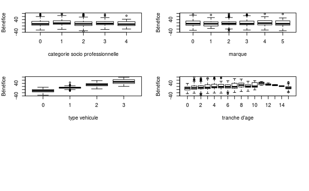

```r
layout(1) #
```

Nous voyons ici que le type vehicule ainsi que la tranche d’age semble effectivement avoir un effet significatif sur le bénéfice net annuel.

Faisons maintenant un anova pour chaque variable qualitative pour vérifier nos hypothèses:

```r
lm.csp = lm(Benefice.net.annuel~le_csp)
anova(lm.csp) # donne la meme sortie que summary(aov)
```

```
Analysis of Variance Table

Response: Benefice.net.annuel
           Df Sum Sq Mean Sq F value   Pr(>F)
le_csp      4   5228 1307.05  3.4945 0.007639 **
Residuals 995 372157  374.03
---
Signif. codes:  0 ‘***’ 0.001 ‘**’ 0.01 ‘*’ 0.05 ‘.’ 0.1 ‘ ’ 1
```

On note une p-value de 0.007 <0.05 donc on rejette l’hypothese nulle. Les données nous permettent donc ici de conclure une corrélation entre la catégorie socio professionnelle et le Bénéfice net annuel.

```r
lm.marque = lm(Benefice.net.annuel~le_marque)
anova(lm.marque)
```

```
Analysis of Variance Table

Response: Benefice.net.annuel
           Df Sum Sq Mean Sq F value Pr(>F)
le_marque   5   1134  226.88  0.5994 0.7005
Residuals 994 376251  378.52
```

```r
lm.tv = lm(Benefice.net.annuel~le_type_vehicule)
anova(lm.tv)
```

```
Analysis of Variance Table

Response: Benefice.net.annuel
                  Df Sum Sq Mean Sq F value    Pr(>F)
le_type_vehicule   3 296709   98903    1221 < 2.2e-16 ***
Residuals        996  80677      81
---
Signif. codes:  0 ‘***’ 0.001 ‘**’ 0.01 ‘*’ 0.05 ‘.’ 0.1 ‘ ’ 1
```

Nous observons une p-value de 2e-16. Ca veut dire que cette variable est tres importante dans notre étude. On a un R2 ajusté de 0.79 donc le modele avec cet unique feature explique 78% du Benefice net annuel. Nous tenons surement l’un des features les plus importants de notre étude.

```r
lm.al = lm(Benefice.net.annuel~age_label)
anova(lm.al)
```

```
Analysis of Variance Table

Response: Benefice.net.annuel
           Df Sum Sq Mean Sq F value    Pr(>F)
age_label  15  25775 1718.32  4.8088 4.346e-09 ***
Residuals 984 351611  357.33
---
Signif. codes:  0 ‘***’ 0.001 ‘**’ 0.01 ‘*’ 0.05 ‘.’ 0.1 ‘ ’ 1
```

Le feature est aussi trop important dans l’explication du bénéfice net annuel. Nous allons donc le garder tout au long de l’étude.

Testons Maintenant les effets des interactions entre les différentes variables qualitatives:

```r
# modele d'Anova avec interactions
lm.all_int = lm(Benefice.net.annuel~le_csp*(le_marque+le_type_vehicule+age_label)+le_marque*(le_type_vehicule+age_label)+le_type_vehicule*age_label)
anova(lm.all_int)
```

```
Analysis of Variance Table

Response: Benefice.net.annuel
                            Df Sum Sq Mean Sq   F value    Pr(>F)
le_csp                       4   5228    1307   21.0766 < 2.2e-16 ***
le_marque                    5   1030     206    3.3230  0.005614 **
le_type_vehicule             3 295791   98597 1589.9098 < 2.2e-16 ***
age_label                   15  10840     723   11.6530 < 2.2e-16 ***
le_csp:le_marque            20   1589      79    1.2813  0.182821
le_csp:le_type_vehicule     12    548      46    0.7359  0.716723
le_csp:age_label            47   3059      65    1.0495  0.385321
le_marque:le_type_vehicule  15   1393      93    1.4975  0.099432 .
le_marque:age_label         56   3852      69    1.1092  0.276276
le_type_vehicule:age_label  33   5126     155    2.5050 8.492e-06 ***
Residuals                  789  48929      62
---
Signif. codes:  0 ‘***’ 0.001 ‘**’ 0.01 ‘*’ 0.05 ‘.’ 0.1 ‘ ’ 1
```

Nous voyons à travers cette sortie que l’interaction type vehicule et age_label est importante pour l’explicabilité du Benefice net annuel avec une p_value < 10e-5. Nous allons donc le prendre en compte.

Pour conclure cette analyse des variables qualitatives, nous retenons que les features importants sont: le type de vehicule, la categorie socio professionnelle, la variable age_label ainsi que l’interaction type_vehicule age_label.

Passons maintenant à une analyse des variables Quantitatives:

Ici nous allons tenter la meme approche: étudier d’abord la distribution de chaque variable pour détecter de potentiels outliers,pour ensuite faire une regression pour voir est ce que notre variable explique bien le bénéfice net annuel:

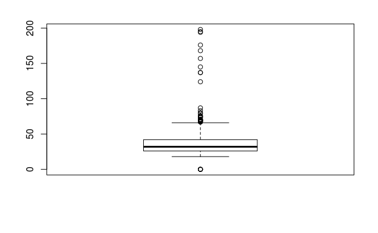

```r
boxplot(Age)
```

Nous observons grace à ce graphe qu’il ya de potentiels outliers à prendre en compte

```r
reg.age= lm(Benefice.net.annuel ~ Age)
anova(reg.age)
```

```
Analysis of Variance Table

Response: Benefice.net.annuel
           Df Sum Sq Mean Sq F value    Pr(>F)
Age         1   6689  6688.7  18.007 2.405e-05 ***
Residuals 998 370697   371.4
---
Signif. codes:  0 ‘***’ 0.001 ‘**’ 0.01 ‘*’ 0.05 ‘.’ 0.1 ‘ ’ 1
```

Avec une p-value <<0.05, nous déduisons qu’il ya un lien entre l’age et le bénéfice net annuel.

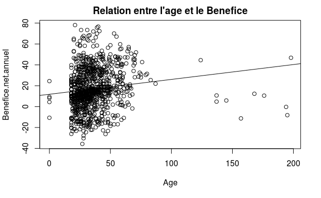

```r
plot(Age,Benefice.net.annuel, main="Relation entre l'age et le Benefice")
abline(reg.age)
```

En visionnant le graphe,il est clair pour nous qu’il faudra une phase de detection d’outliers dans notre case study.

Analysons maintenant le coefficient bonus malus:

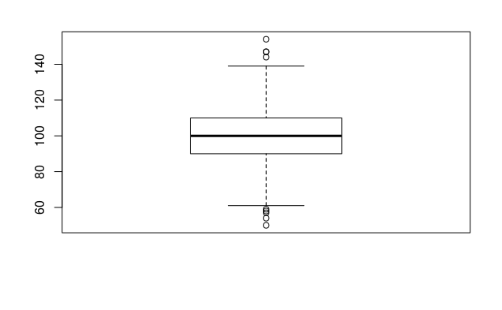

```r
boxplot(Coefficient.bonus.malus)
```

```r
reg.cbm= lm(Benefice.net.annuel ~ Coefficient.bonus.malus)
anova(reg.cbm)
```

```
Analysis of Variance Table

Response: Benefice.net.annuel
                         Df Sum Sq Mean Sq F value  Pr(>F)
Coefficient.bonus.malus   1   1882 1881.96  5.0018 0.02554 *
Residuals               998 375504  376.26
---
Signif. codes:  0 ‘***’ 0.001 ‘**’ 0.01 ‘*’ 0.05 ‘.’ 0.1 ‘ ’ 1
```

Le test d’effet sur le bénéfice de cette variable est aussi significatif.

Analyse du cout d’entretient annuel:

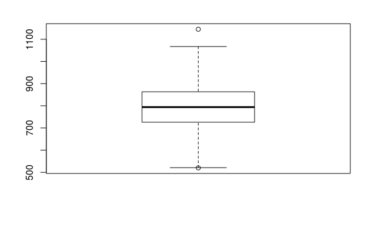

```r
boxplot(Cout.entretien.annuel)
```

```r
reg.cea= lm(Benefice.net.annuel ~ Cout.entretien.annuel)
anova(reg.cea)
```

```
Analysis of Variance Table

Response: Benefice.net.annuel
                       Df Sum Sq Mean Sq F value Pr(>F)
Cout.entretien.annuel   1     85   85.30  0.2256 0.6349
Residuals             998 377300  378.06
```

Ici par exemple, nous avons une p-value>>0.05. L’hypothese Ho du test de nullité du coefficient associé au cout d’entretien annuel est donc accceptée. Nous en concluons que cette variable n’a pas d’effet sur le Bénéfice net annuel.

Le code suivant permet de faire cette même étude pour toutes les autres variables quantitatives.

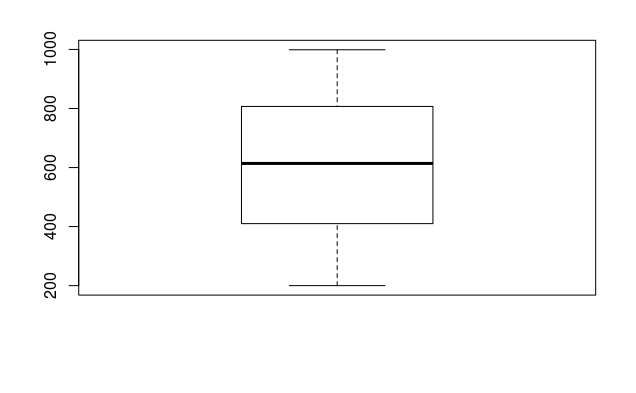

```r
boxplot(Kilometres.parcourus.par.mois)
```

```r
reg.kpm= lm(Benefice.net.annuel ~ Kilometres.parcourus.par.mois)
summary(reg.kpm)
```

```
Call:
lm(formula = Benefice.net.annuel ~ Kilometres.parcourus.par.mois)

Residuals:
    Min      1Q  Median      3Q     Max
-51.790 -10.512  -2.008  13.976  58.178

Coefficients:
                               Estimate Std. Error t value Pr(>|t|)
(Intercept)                   12.184700   1.709634   7.127 1.96e-12 ***
Kilometres.parcourus.par.mois  0.007910   0.002636   3.001  0.00275 **
---
Signif. codes:  0 ‘***’ 0.001 ‘**’ 0.01 ‘*’ 0.05 ‘.’ 0.1 ‘ ’ 1

Residual standard error: 19.36 on 998 degrees of freedom
Multiple R-squared:  0.008946,  Adjusted R-squared:  0.007953
F-statistic: 9.009 on 1 and 998 DF,  p-value: 0.002754
```

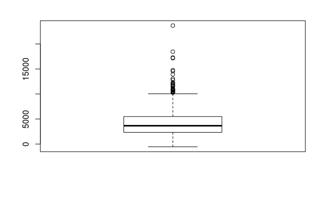

```r
boxplot(Niveau.de.vie)
```

```r
reg.ndv= lm(Benefice.net.annuel ~ Niveau.de.vie)
summary(reg.ndv)
```

```
Call:
lm(formula = Benefice.net.annuel ~ Niveau.de.vie)

Residuals:
    Min      1Q  Median      3Q     Max
-42.617  -9.928  -3.082  13.495  57.744

Coefficients:
                Estimate Std. Error t value Pr(>|t|)
(Intercept)   22.1957655  1.1327977  19.594  < 2e-16 ***
Niveau.de.vie -0.0012407  0.0002275  -5.454 6.21e-08 ***
---
Signif. codes:  0 ‘***’ 0.001 ‘**’ 0.01 ‘*’ 0.05 ‘.’ 0.1 ‘ ’ 1

Residual standard error: 19.16 on 998 degrees of freedom
Multiple R-squared:  0.02894,   Adjusted R-squared:  0.02797
F-statistic: 29.75 on 1 and 998 DF,  p-value: 6.213e-08
```

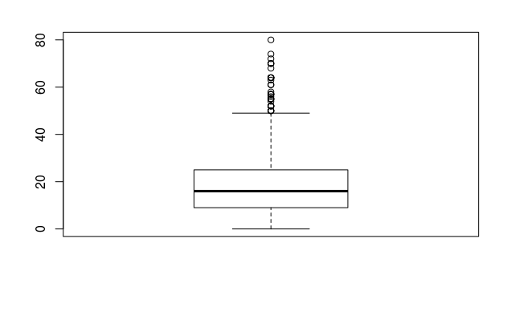

```r
boxplot((Prime.mensuelle))
```

```r
reg.pm= lm(Benefice.net.annuel ~ Prime.mensuelle)
summary(reg.pm)
```

```
Call:
lm(formula = Benefice.net.annuel ~ Prime.mensuelle)

Residuals:
    Min      1Q  Median      3Q     Max
-52.894 -11.079  -2.611  13.433  60.901

Coefficients:
                Estimate Std. Error t value Pr(>|t|)
(Intercept)     17.35409    1.07100  16.204   <2e-16 ***
Prime.mensuelle -0.02009    0.04659  -0.431    0.666
---
Signif. codes:  0 ‘***’ 0.001 ‘**’ 0.01 ‘*’ 0.05 ‘.’ 0.1 ‘ ’ 1

Residual standard error: 19.44 on 998 degrees of freedom
Multiple R-squared:  0.0001864, Adjusted R-squared:  -0.0008154
F-statistic: 0.1861 on 1 and 998 DF,  p-value: 0.6663
```

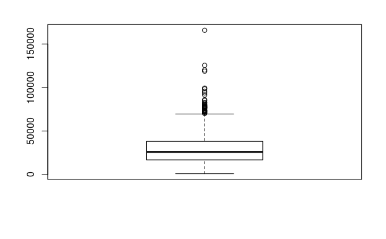

```r
boxplot(Salaire.annuel)
```

```r
reg.sa= lm(Benefice.net.annuel ~ Salaire.annuel)
summary(reg.sa)
```

```
Call:
lm(formula = Benefice.net.annuel ~ Salaire.annuel)

Residuals:
    Min      1Q  Median      3Q     Max
-43.085  -9.716  -3.167  13.433  57.055

Coefficients:
                 Estimate Std. Error t value Pr(>|t|)
(Intercept)     2.261e+01  1.161e+00   19.47  < 2e-16 ***
Salaire.annuel -1.908e-04  3.354e-05   -5.69 1.67e-08 ***
---
Signif. codes:  0 ‘***’ 0.001 ‘**’ 0.01 ‘*’ 0.05 ‘.’ 0.1 ‘ ’ 1

Residual standard error: 19.14 on 998 degrees of freedom
Multiple R-squared:  0.03142,   Adjusted R-squared:  0.03045
F-statistic: 32.37 on 1 and 998 DF,  p-value: 1.673e-08
```

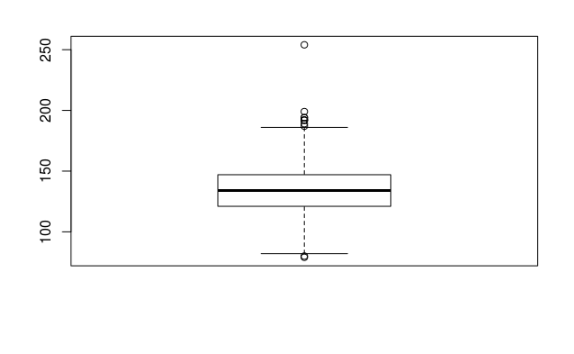

```r
boxplot(Score.CRM)
```

```r
reg.crm= lm(Benefice.net.annuel ~ Score.CRM)
summary(reg.crm)
```

```
Call:
lm(formula = Benefice.net.annuel ~ Score.CRM)

Residuals:
    Min      1Q  Median      3Q     Max
-49.019 -10.378  -2.142  13.081  63.220

Coefficients:
            Estimate Std. Error t value Pr(>|t|)
(Intercept) -6.93389    4.03951  -1.717   0.0864 .
Score.CRM    0.17747    0.02965   5.986 2.99e-09 ***
---
Signif. codes:  0 ‘***’ 0.001 ‘**’ 0.01 ‘*’ 0.05 ‘.’ 0.1 ‘ ’ 1

Residual standard error: 19.11 on 998 degrees of freedom
Multiple R-squared:  0.03466,   Adjusted R-squared:  0.0337
F-statistic: 35.84 on 1 and 998 DF,  p-value: 2.991e-09
```

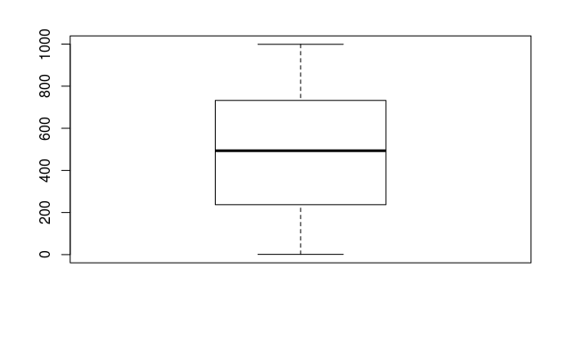

```r
boxplot(Score.credit)
```

```r
reg.sc= lm(Benefice.net.annuel ~ Score.credit)
summary(reg.sc)
```

```
Call:
lm(formula = Benefice.net.annuel ~ Score.credit)

Residuals:
    Min      1Q  Median      3Q     Max
-52.507 -10.864  -2.593  13.270  60.624

Coefficients:
              Estimate Std. Error t value Pr(>|t|)
(Intercept)  16.333872   1.218024  13.410   <2e-16 ***
Score.credit  0.001300   0.002129   0.611    0.542
---
Signif. codes:  0 ‘***’ 0.001 ‘**’ 0.01 ‘*’ 0.05 ‘.’ 0.1 ‘ ’ 1

Residual standard error: 19.44 on 998 degrees of freedom
Multiple R-squared:  0.0003734, Adjusted R-squared:  -0.0006283
F-statistic: 0.3728 on 1 and 998 DF,  p-value: 0.5416
```

Construisons un modele de regression en considèrant toutes les variables quantitatives pour avoir une baseline pour la feature selection

```r
reg_all_q = lm(Benefice.net.annuel ~ Age+Coefficient.bonus.malus+Kilometres.parcourus.par.mois+Prime.mensuelle+Score.CRM+Cout.entretien.annuel+Niveau.de.vie+Salaire.annuel+Score.credit)
anova(reg_all_q)
```

```
Analysis of Variance Table

Response: Benefice.net.annuel
                               Df Sum Sq Mean Sq F value    Pr(>F)
Age                             1   6689  6688.7 19.2276 1.284e-05 ***
Coefficient.bonus.malus         1   1898  1898.0  5.4562  0.019698 *
Kilometres.parcourus.par.mois   1   2998  2998.2  8.6187  0.003404 **
Prime.mensuelle                 1    134   134.0  0.3851  0.535007
Score.CRM                       1   8296  8296.3 23.8492 1.214e-06 ***
Cout.entretien.annuel           1     74    73.9  0.2125  0.644947
Niveau.de.vie                   1  11354 11354.2 32.6396 1.467e-08 ***
Salaire.annuel                  1   1505  1504.9  4.3261  0.037789 *
Score.credit                    1     49    49.0  0.1409  0.707440
Residuals                     990 344388   347.9
---
Signif. codes:  0 ‘***’ 0.001 ‘**’ 0.01 ‘*’ 0.05 ‘.’ 0.1 ‘ ’ 1
```

La sortie nous montre que L’age, le score crm et le niveua de vie sont les plus importantes car ceux sont celles qui sont associées aux plus petites p-values

Faisons maintenant un feature selection par la méthode descendante sur ce modèle:

```r
regback = step(reg_all_q, direction = c("backward")) # descendant
```

```
Start:  AIC=5861.77
Benefice.net.annuel ~ Age + Coefficient.bonus.malus + Kilometres.parcourus.par.mois +
    Prime.mensuelle + Score.CRM + Cout.entretien.annuel + Niveau.de.vie +
    Salaire.annuel + Score.credit

                                Df Sum of Sq    RSS    AIC
- Cout.entretien.annuel          1      24.1 344413 5859.8
- Age                            1      48.8 344437 5859.9
- Score.credit                   1      49.0 344437 5859.9
- Niveau.de.vie                  1     361.6 344750 5860.8
- Prime.mensuelle                1     445.7 344834 5861.1
<none>                                       344388 5861.8
- Salaire.annuel                 1    1508.2 345897 5864.1
- Coefficient.bonus.malus        1    2522.0 346910 5867.1
- Kilometres.parcourus.par.mois  1    3059.0 347447 5868.6
- Score.CRM                      1    8704.2 353093 5884.7

Step:  AIC=5859.84
Benefice.net.annuel ~ Age + Coefficient.bonus.malus + Kilometres.parcourus.par.mois +
    Prime.mensuelle + Score.CRM + Niveau.de.vie + Salaire.annuel +
    Score.credit

                                Df Sum of Sq    RSS    AIC
- Score.credit                   1      48.8 344461 5858.0
- Age                            1      50.4 344463 5858.0
- Niveau.de.vie                  1     363.7 344776 5858.9
- Prime.mensuelle                1     442.4 344855 5859.1
<none>                                       344413 5859.8
- Salaire.annuel                 1    1514.9 345927 5862.2
- Coefficient.bonus.malus        1    2517.8 346930 5865.1
- Kilometres.parcourus.par.mois  1    3052.2 347465 5866.7
- Score.CRM                      1    8698.5 353111 5882.8

Step:  AIC=5857.98
Benefice.net.annuel ~ Age + Coefficient.bonus.malus + Kilometres.parcourus.par.mois +
    Prime.mensuelle + Score.CRM + Niveau.de.vie + Salaire.annuel

                                Df Sum of Sq    RSS    AIC
- Age                            1      48.2 344510 5856.1
- Niveau.de.vie                  1     361.7 344823 5857.0
```

[output cut: 27 more lines]

```
- Kilometres.parcourus.par.mois  1    3110.0 347983 5862.2
- Coefficient.bonus.malus        1    3934.4 348807 5864.5
- Salaire.annuel                 1   12549.6 357422 5888.9
- Score.CRM                      1   15398.3 360271 5896.9

Step:  AIC=5854.43
Benefice.net.annuel ~ Coefficient.bonus.malus + Kilometres.parcourus.par.mois +
    Score.CRM + Salaire.annuel

                                Df Sum of Sq    RSS    AIC
<none>                                       345305 5854.4
- Kilometres.parcourus.par.mois  1    3079.9 348385 5861.3
- Coefficient.bonus.malus        1    3987.7 349293 5863.9
- Salaire.annuel                 1   12270.2 357575 5887.3
- Score.CRM                      1   15336.5 360641 5895.9
```

```r
anova(regback)
```

```
Analysis of Variance Table

Response: Benefice.net.annuel
                               Df Sum Sq Mean Sq F value    Pr(>F)
Coefficient.bonus.malus         1   1882  1882.0  5.4229  0.020074 *
Kilometres.parcourus.par.mois   1   3195  3195.3  9.2072  0.002473 **
Score.CRM                       1  14733 14733.3 42.4543 1.147e-10 ***
Salaire.annuel                  1  12270 12270.2 35.3566 3.796e-09 ***
Residuals                     995 345305   347.0
---
Signif. codes:  0 ‘***’ 0.001 ‘**’ 0.01 ‘*’ 0.05 ‘.’ 0.1 ‘ ’ 1
```

Lorsque nous mettons tous les features ensemble, nous voyons que le score CRM, le salaire Annuel Le nombre de Kms parcourus ainsi que le Coefficient Bonus Malus sont les variables quantitatives qui expliquent le mieux le Benefice en minimisant le critère d’AIC (passage de 5861 à 5854).

Reessayons maintenant mais en ne gardant que les features qui nous semblaient cohérents aprés avoir fait les tests individuellement:

```r
reg_all_qe = lm(Benefice.net.annuel ~ Age+Coefficient.bonus.malus+Kilometres.parcourus.par.mois+Score.CRM+Niveau.de.vie+Salaire.annuel)
regbacke = step(reg_all_qe, direction = c("backward")) # descendant
```

```
Start:  AIC=5857.26
Benefice.net.annuel ~ Age + Coefficient.bonus.malus + Kilometres.parcourus.par.mois +
    Score.CRM + Niveau.de.vie + Salaire.annuel

                                Df Sum of Sq    RSS    AIC
- Age                            1      48.3 344950 5855.4
- Niveau.de.vie                  1     354.0 345255 5856.3
<none>                                       344901 5857.3
- Salaire.annuel                 1    1474.7 346376 5859.5
- Coefficient.bonus.malus        1    2558.2 347460 5862.6
- Kilometres.parcourus.par.mois  1    3047.6 347949 5864.1
- Score.CRM                      1    8698.5 353600 5880.2

Step:  AIC=5855.4
Benefice.net.annuel ~ Coefficient.bonus.malus + Kilometres.parcourus.par.mois +
    Score.CRM + Niveau.de.vie + Salaire.annuel

                                Df Sum of Sq    RSS    AIC
- Niveau.de.vie                  1     355.3 345305 5854.4
<none>                                       344950 5855.4
- Salaire.annuel                 1    1477.4 346427 5857.7
- Kilometres.parcourus.par.mois  1    3071.7 348021 5862.3
- Coefficient.bonus.malus        1    3897.7 348847 5864.6
- Score.CRM                      1   15398.3 360348 5897.1

Step:  AIC=5854.43
Benefice.net.annuel ~ Coefficient.bonus.malus + Kilometres.parcourus.par.mois +
    Score.CRM + Salaire.annuel

                                Df Sum of Sq    RSS    AIC
<none>                                       345305 5854.4
- Kilometres.parcourus.par.mois  1    3079.9 348385 5861.3
- Coefficient.bonus.malus        1    3987.7 349293 5863.9
- Salaire.annuel                 1   12270.2 357575 5887.3
- Score.CRM                      1   15336.5 360641 5895.9
```

```r
anova(regbacke)
```

```
Analysis of Variance Table

Response: Benefice.net.annuel
                               Df Sum Sq Mean Sq F value    Pr(>F)
Coefficient.bonus.malus         1   1882  1882.0  5.4229  0.020074 *
Kilometres.parcourus.par.mois   1   3195  3195.3  9.2072  0.002473 **
Score.CRM                       1  14733 14733.3 42.4543 1.147e-10 ***
Salaire.annuel                  1  12270 12270.2 35.3566 3.796e-09 ***
Residuals                     995 345305   347.0
---
Signif. codes:  0 ‘***’ 0.001 ‘**’ 0.01 ‘*’ 0.05 ‘.’ 0.1 ‘ ’ 1
```

Ceci confirme notre hypothese donc nous allons nous concentrer sur ces features dans la construction de notre modèle.

Maintenant, nous fusionnons les features retenus dans chacune des phases d’études des différents types de variables (quantitatives et qualitatives) afin de construire un modèle final. Nous retiendrons comme features principales celles qu’on aura aprés une étape de feature selection avec la méthode descendante:

```r
lm_all = lm(Benefice.net.annuel ~Coefficient.bonus.malus+Kilometres.parcourus.par.mois+Score.CRM+Salaire.annuel+le_type_vehicule+le_csp+age_label+age_label*le_type_vehicule)
anova(lm_all)
```

```
Analysis of Variance Table

Response: Benefice.net.annuel
                               Df Sum Sq Mean Sq   F value    Pr(>F)
Coefficient.bonus.malus         1   1882    1882   44.1882 5.057e-11 ***
Kilometres.parcourus.par.mois   1   3195    3195   75.0244 < 2.2e-16 ***
Score.CRM                       1  14733   14733  345.9373 < 2.2e-16 ***
Salaire.annuel                  1  12270   12270  288.1023 < 2.2e-16 ***
le_type_vehicule                3 295709   98570 2314.4089 < 2.2e-16 ***
le_csp                          4   4412    1103   25.9012 < 2.2e-16 ***
age_label                      15   1257      84    1.9672   0.01491 *
le_type_vehicule:age_label     36   4020     112    2.6219 9.869e-07 ***
Residuals                     937  39906      43
---
Signif. codes:  0 ‘***’ 0.001 ‘**’ 0.01 ‘*’ 0.05 ‘.’ 0.1 ‘ ’ 1
```

Nous voyons ici que toutes nos variables sont importantes pour expliquer le benefice net annuel. Regardons maintenant à quel point nos variables expliquent le benefice.

```r
summary(lm_all)
```

```
Call:
lm(formula = Benefice.net.annuel ~ Coefficient.bonus.malus +
    Kilometres.parcourus.par.mois + Score.CRM + Salaire.annuel +
    le_type_vehicule + le_csp + age_label + age_label * le_type_vehicule)

Residuals:
    Min      1Q  Median      3Q     Max
-22.722  -3.085   0.000   2.991  21.344

Coefficients: (9 not defined because of singularities)
                                Estimate Std. Error t value Pr(>|t|)
(Intercept)                   -2.308e+01  2.334e+00  -9.889  < 2e-16 ***
Coefficient.bonus.malus       -4.357e-02  3.638e-02  -1.198 0.231384
Kilometres.parcourus.par.mois  8.179e-03  9.168e-04   8.921  < 2e-16 ***
Score.CRM                      1.177e-01  3.319e-02   3.546 0.000411 ***
Salaire.annuel                -2.184e-04  1.169e-05 -18.683  < 2e-16 ***
le_type_vehicule1              2.115e+01  2.112e+00  10.017  < 2e-16 ***
le_type_vehicule2              3.781e+01  2.282e+00  16.570  < 2e-16 ***
le_type_vehicule3              4.330e+01  4.909e+00   8.820  < 2e-16 ***
le_csp1                        3.929e+00  5.361e-01   7.330 4.98e-13 ***
le_csp2                        7.554e-02  5.808e-01   0.130 0.896538
le_csp3                        4.657e+00  7.836e-01   5.943 3.95e-09 ***
le_csp4                       -6.566e-01  1.005e+00  -0.653 0.513813
age_label1                     4.783e+00  1.971e+00   2.427 0.015428 *
age_label2                     4.186e+00  1.936e+00   2.163 0.030832 *
age_label3                     2.547e+00  2.010e+00   1.267 0.205470
age_label4                     7.476e+00  2.255e+00   3.316 0.000949 ***
age_label5                     1.412e+00  2.350e+00   0.601 0.548025
age_label6                     5.502e+00  2.478e+00   2.221 0.026622 *
age_label7                     3.014e+00  3.047e+00   0.989 0.322859
age_label8                     1.142e+01  3.080e+00   3.707 0.000222 ***
age_label9                     1.079e+01  3.655e+00   2.953 0.003224 **
age_label10                    1.249e+01  3.967e+00   3.148 0.001693 **
age_label11                    1.700e+01  8.266e+00   2.056 0.040019 *
age_label12                    1.017e+01  5.325e+00   1.910 0.056393 .
age_label13                    7.081e+00  7.030e+00   1.007 0.314038
age_label14                    1.015e+01  7.088e+00   1.433 0.152305
age_label15                    3.162e+00  3.170e+00   0.997 0.318869
le_type_vehicule1:age_label1  -4.931e+00  2.535e+00  -1.945 0.052107 .
le_type_vehicule2:age_label1  -3.143e+00  2.741e+00  -1.147 0.251848
```

[output cut: 34 more lines]

```
le_type_vehicule1:age_label13  2.347e+00  9.537e+00   0.246 0.805662
le_type_vehicule2:age_label13         NA         NA      NA       NA
le_type_vehicule3:age_label13         NA         NA      NA       NA
le_type_vehicule1:age_label14         NA         NA      NA       NA
le_type_vehicule2:age_label14         NA         NA      NA       NA
le_type_vehicule3:age_label14         NA         NA      NA       NA
le_type_vehicule1:age_label15 -8.943e-02  3.823e+00  -0.023 0.981342
le_type_vehicule2:age_label15 -3.212e-01  4.407e+00  -0.073 0.941911
le_type_vehicule3:age_label15         NA         NA      NA       NA
---
Signif. codes:  0 ‘***’ 0.001 ‘**’ 0.01 ‘*’ 0.05 ‘.’ 0.1 ‘ ’ 1

Residual standard error: 6.526 on 937 degrees of freedom
Multiple R-squared:  0.8943,    Adjusted R-squared:  0.8873
F-statistic: 127.8 on 62 and 937 DF,  p-value: < 2.2e-16
```

Nous obtenons un R2-ajusté de 0.8873, ce qui veut dire que notre modèle explique à environ 90% le Benefice net annuel. Ce qui est assez solide.

Faisons une automatique feature selection avec les variables qualitatives et quantitatives pour ne garder que celles qui minimisent notre AIC:

```r
regback_all = step(lm_all, direction = c("backward")) # descendant
```

```
Start:  AIC=3812.54
Benefice.net.annuel ~ Coefficient.bonus.malus + Kilometres.parcourus.par.mois +
    Score.CRM + Salaire.annuel + le_type_vehicule + le_csp +
    age_label + age_label * le_type_vehicule

                                Df Sum of Sq   RSS    AIC
- Coefficient.bonus.malus        1      61.1 39968 3812.1
<none>                                       39906 3812.5
- Score.CRM                      1     535.5 40442 3823.9
- le_type_vehicule:age_label    36    4019.9 43926 3836.5
- Kilometres.parcourus.par.mois  1    3389.6 43296 3892.1
- le_csp                         4    3892.6 43799 3897.6
- Salaire.annuel                 1   14866.8 54773 4127.2

Step:  AIC=3812.07
Benefice.net.annuel ~ Kilometres.parcourus.par.mois + Score.CRM +
    Salaire.annuel + le_type_vehicule + le_csp + age_label +
    le_type_vehicule:age_label

                                Df Sum of Sq   RSS    AIC
<none>                                       39968 3812.1
- le_type_vehicule:age_label    36    4035.0 44003 3836.2
- Score.CRM                      1    1633.8 41601 3850.1
- Kilometres.parcourus.par.mois  1    3373.8 43341 3891.1
- le_csp                         4    3908.9 43876 3897.4
- Salaire.annuel                 1   14820.5 54788 4125.5
```

```r
anova(regback_all)
```

```
Analysis of Variance Table

Response: Benefice.net.annuel
                               Df Sum Sq Mean Sq   F value    Pr(>F)
Kilometres.parcourus.par.mois   1   3376    3376   79.2340 < 2.2e-16 ***
Score.CRM                       1  12736   12736  298.8981 < 2.2e-16 ***
Salaire.annuel                  1  11981   11981  281.1852 < 2.2e-16 ***
le_type_vehicule                3 297065   99022 2323.9422 < 2.2e-16 ***
le_csp                          4   4485    1121   26.3126 < 2.2e-16 ***
age_label                      15   3741     249    5.8525 1.043e-11 ***
le_type_vehicule:age_label     36   4035     112    2.6305 8.992e-07 ***
Residuals                     938  39968      43
---
Signif. codes:  0 ‘***’ 0.001 ‘**’ 0.01 ‘*’ 0.05 ‘.’ 0.1 ‘ ’ 1
```

Nous concluons que les six (06) features qui expliquent le mieux le Benefice net annuel sont:

```
          - Le nombre de Kms parcourus
          - Le score CRM
          - Le Salaire annuel
          - le Type vehicule
          - La catégorie Socio professionnelle
          - La variable age_label qui classent les ages des beneficiares par intervalles.
```

C’est donc de ces variables dont nous allons nous servir dans la suite de l’Etude afin de construire notre modèle prédictif.